# will_Lab10

## Simple rules to judge a question

We are curious about what make the question or answer in the dataset to be a good/bad one.

Straightforwardly, we find two coarse features, *i.e.* the length of the title and body of the questions.

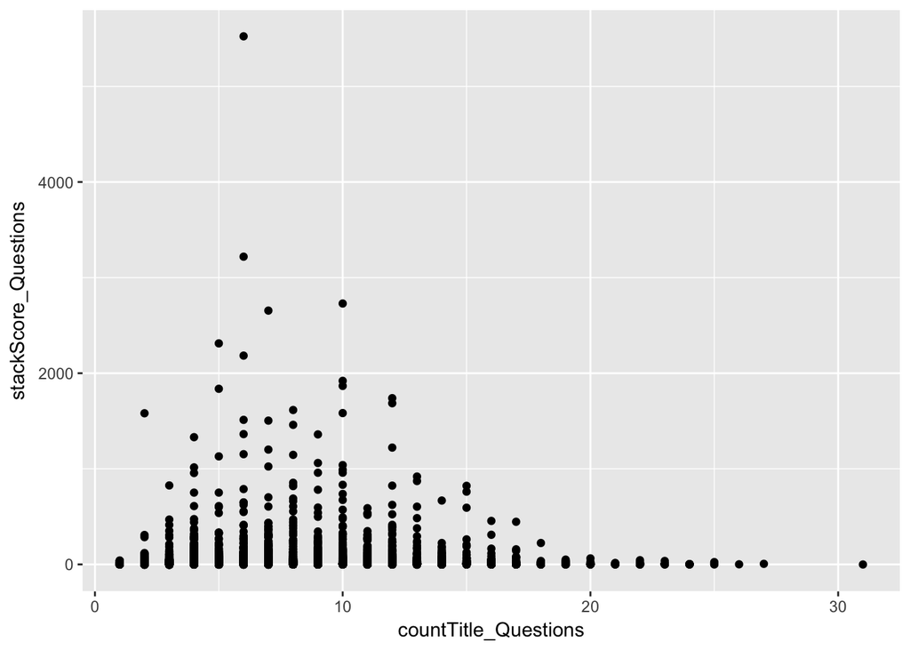

```r
stackQuestions <- read.csv("Questions_trunc.csv",header= TRUE, sep = ",")
stackScore_Questions <- stackQuestions$Score
countBody_Questions <- sapply(gregexpr("\\W+", stackQuestions$Body), length)
countTitle_Questions <- sapply(gregexpr("\\W+", stackQuestions$Title), length)

df <- data.frame(countTitle_Questions, stackScore_Questions)
df2 <- data.frame(countBody_Questions, stackScore_Questions)


ggplt <- ggplot(df, aes(x = countTitle_Questions, y = stackScore_Questions)) + geom_point()

ggplt2 <- ggplot(df, aes(x = countBody_Questions, y = stackScore_Questions)) + geom_point()



ggplt
```

It coincides with our first thought, a good question is with a balanced length of title.

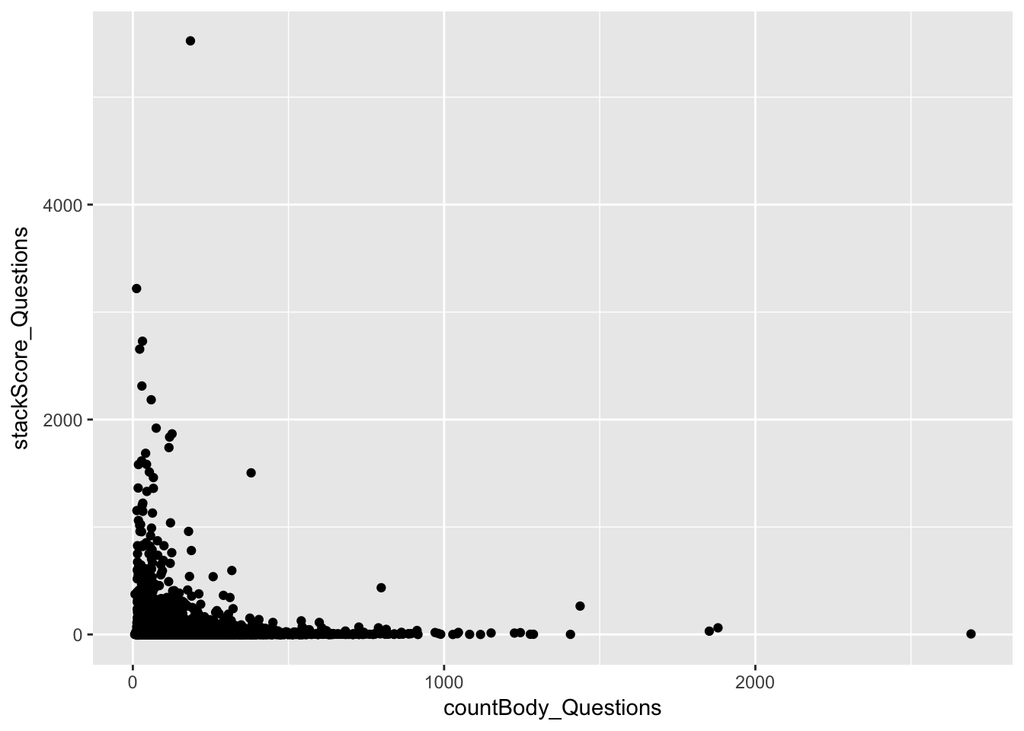

```r
ggplt2
```

On the other side, from the graph above, we can draw the conclusion that the quality of a question has a negative correction with the length of body of the question.

But the feature is too coarse to character how to be a good question.

## Simple rules to judge an answer

Intuitively, the answer is too long or, too short, it may not be good enough.

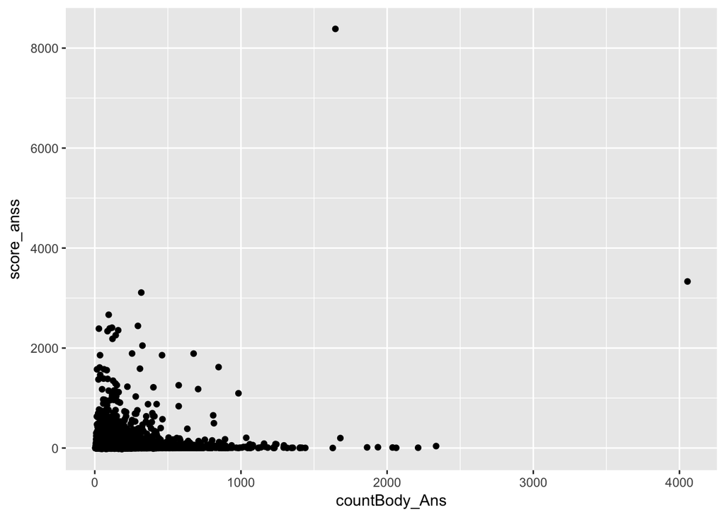

```r
stackAnss <- read.csv("Answers_trunc.csv", header = TRUE, sep = ",")
score_anss <- stackAnss$Score
countBody_Ans <- sapply(gregexpr("\\W+", stackAnss$Body), length)
df3 <- data.frame(countBody_Ans, score_anss)

ggplt3 <- ggplot(df3, aes(x = countBody_Ans, y = score_anss)) + geom_point()
ggplt3
```

From the plot, we can see most of the answers are less than 1000 words. From practical point of view, too long meeans impatience. So a balanced length of the answer can improve the quality of the answer. Elegancy and simpleness can earn a good score.

But again this feature is too coarse to character how to be a good answer.